# Machine Learning Engineer Nanodegree

## *San Francisco Crime Classification*

San Francisco used to be known for housing some of the world’s most notorious criminals on the island of Alcatraz. Today, it is known more for its tech scene that its criminal past. However, nowadays there is no scarcity of crime in the city. In this project, a training dataset with nearly 12 years of crime reports from all across San Francisco’s neighbourhoods was provided from kaggle competition This dataset contains all crimes classified in categories, which are the different crime typologies. The main goal of the challenge is to predict this categories of the crimes that occurred. For the algorithm evaluation, another unlabelled dataset is provided (the test one). It is used to evaluate the algorithm accuracy with new unclassified data. Results from the algorithm executions have to be submitted (uploaded) to Kaggle website. These submissions are .csv files with a specific format. When uploaded, they are evaluated against the test database and they are given a score using the Logloss function.

## Data Analysis

The provided dataset has different “features”, each one being of a different relevance. we will proceed to analyse this database and extract the useful information out of it.

### Data reading

```python
import numpy as np
import pandas as pd
train = pd.read_csv('all/train.csv', parse_dates = ['Dates'])
test = pd.read_csv('all/test.csv', parse_dates = ['Dates'])

print(train.head())
```

```
                Dates        Category                      Descript  \
0 2015-05-13 23:53:00        WARRANTS                WARRANT ARREST
1 2015-05-13 23:53:00  OTHER OFFENSES      TRAFFIC VIOLATION ARREST
2 2015-05-13 23:33:00  OTHER OFFENSES      TRAFFIC VIOLATION ARREST
3 2015-05-13 23:30:00   LARCENY/THEFT  GRAND THEFT FROM LOCKED AUTO
4 2015-05-13 23:30:00   LARCENY/THEFT  GRAND THEFT FROM LOCKED AUTO

   DayOfWeek PdDistrict      Resolution                    Address  \
0  Wednesday   NORTHERN  ARREST, BOOKED         OAK ST / LAGUNA ST
1  Wednesday   NORTHERN  ARREST, BOOKED         OAK ST / LAGUNA ST
2  Wednesday   NORTHERN  ARREST, BOOKED  VANNESS AV / GREENWICH ST
3  Wednesday   NORTHERN            NONE   1500 Block of LOMBARD ST
4  Wednesday       PARK            NONE  100 Block of BRODERICK ST

            X          Y
0 -122.425892  37.774599
1 -122.425892  37.774599
2 -122.424363  37.800414
3 -122.426995  37.800873
4 -122.438738  37.771541
```

### Data visualization

And now we will visualize the relation between features (X,Y,DayOfWeek,PdDistrict,..) and the target (Category)

**First we will show the number of occurrence of each Category.**

```
('Number of different Categories =', 39)
```

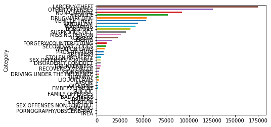

```python
print('Number of different Categories =',train.Category.unique().shape[0])
category_graph = train.groupby('Category')['X'].count()
category_graph.sort_values(ascending=True).plot(kind='barh')
```

We could see that there are 39 different categories and the above plot shows that crimes are not equally distributed among categories but there is a huge difference between them.

**Relation between Categories and the day of week**

```
Index([            0,             1,             2,             3,
                   4,             5,             6,             7,
                   8,             9,            10,            11,
                  12,            13,            14,            15,
                  16,            17,            18,            19,
                  20,            21,            22,            23,
           u'Friday',     u'Monday',   u'Saturday',     u'Sunday',
         u'Thursday',    u'Tuesday',  u'Wednesday',    u'BAYVIEW',
          u'CENTRAL',  u'INGLESIDE',    u'MISSION',   u'NORTHERN',
             u'PARK',   u'RICHMOND',   u'SOUTHERN',    u'TARAVAL',
       u'TENDERLOIN',      u'Dates',   u'Category',   u'Descript',
        u'DayOfWeek', u'PdDistrict', u'Resolution',    u'Address',
                u'X',          u'Y'],
      dtype='object')
```

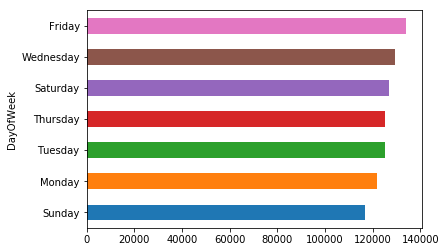

```python
days = pd.get_dummies(train.DayOfWeek)
district = pd.get_dummies(train.PdDistrict)
hour = train.Dates.dt.hour
hour = pd.get_dummies(hour)
new_train_data = pd.concat([hour, days, district, train], axis=1)
print(new_train_data.columns)
day_filter = new_train_data.groupby('DayOfWeek')['X'].count()
day_filter.sort_values(ascending=True).plot(kind='barh')
```

From the plot we could see that crime also distributed over days and **Friday** is the most selected day by criminals, while the rest of the week is pretty equally distributed.

**Visualize Location Information**

```python
print ("Longitudes summary:")
print (train.X.describe())
print ("\nLatitudes summary:")
print (train.Y.describe())
```

```
Longitudes summary:
count    878049.000000
mean       -122.422616
std           0.030354
min        -122.513642
25%        -122.432952
50%        -122.416420
75%        -122.406959
max        -120.500000
Name: X, dtype: float64

Latitudes summary:
count    878049.000000
mean         37.771020
std           0.456893
min          37.707879
25%          37.752427
50%          37.775421
75%          37.784369
max          90.000000
Name: Y, dtype: float64
```

We could see that longitudes values are between [-122.52, -120.5] and latitudes values are between [37.708, 90]. Here we can see bad values and thats because san fransisco latitudes are between [37.707, 37.83269]and longitudes are between [-122.517652, -122.3275] , so we can say that there are some abnormalities in the dataset.  
Now, to demonstrate the locations, let's plot them using scatter plot

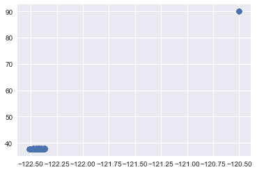

```python
import matplotlib.pyplot as plt
%matplotlib inline
plt.scatter(train.X, train.Y)
plt.show()
```

## Data transformation

To use the dataSet in classification, we must reformate it to numbers instead of strings to be used in classification algorithms and also we have to remove outliers to avoid skewing results which take into consideration these data points.

```python
import math
def transform(data):
    alpha = (2*math.pi)/24
    (hours,minutes,seconds) = (data.Dates.dt.hour, data.Dates.dt.minute, data.Dates.dt.second)
    time = hours + (minutes / 60) + (seconds / 3600)
    TimeX = math.cos(alpha) * time
    TimeY = math.sin(alpha) * time
    TimeX = pd.DataFrame(data={'TimeX':TimeX})
    TimeY = pd.DataFrame(data={'TimeY':TimeY})
    del data['Dates']
    # convert Day of week to Cartesian coordinates
    from sklearn import preprocessing
    daysMapper = preprocessing.LabelEncoder()
    dayNumber = daysMapper.fit_transform(data.DayOfWeek)
    beta = (2*math.pi)/7
    dayX = [ math.cos(beta*d) for d in dayNumber ]
    dayY = [ math.sin(beta*d) for d in dayNumber ]
    dayX = pd.DataFrame(data={'dayX':dayX})
    dayY = pd.DataFrame(data={'dayY':dayY})
    del data['DayOfWeek']
    # delete PdDistrict and Address
    del data['PdDistrict']
    del data['Address']
    transformed_data = pd.concat([data,dayX,dayY,TimeX,TimeY],axis=1)
    # eliminate rows with latitudes out of San Francisco range
    transformed_data = transformed_data.drop(transformed_data[(transformed_data['Y'] > 37.84) | (transformed_data['Y'] < 37.7)].index)
    # eliminate rows with longitudes out of San Francisco range
    transformed_data = transformed_data.drop(transformed_data[((transformed_data['X'] > -122.32) | (transformed_data['X'] < -122.52))].index)
    return transformed_data
```

**We will use the transform method to reformat the input training and testing set**

```python
transformed_data = transform(train)
transformed_data = transformed_data.drop(['Descript','Resolution'],axis=1)
transformed_test = transform(test)
transformed_test = transformed_test.drop(['Id'],axis=1)
print(transformed_data.head())
print(transformed_data.X.describe())
print(transformed_data.Y.describe())
```

```
         Category           X          Y     dayX      dayY      TimeX  \
0        WARRANTS -122.425892  37.774599  0.62349 -0.781831  23.069528
1  OTHER OFFENSES -122.425892  37.774599  0.62349 -0.781831  23.069528
2  OTHER OFFENSES -122.424363  37.800414  0.62349 -0.781831  22.747553
3   LARCENY/THEFT -122.426995  37.800873  0.62349 -0.781831  22.699257
4   LARCENY/THEFT -122.438738  37.771541  0.62349 -0.781831  22.699257

      TimeY
0  6.181462
1  6.181462
2  6.095189
3  6.082248
4  6.082248
count    877982.000000
mean       -122.422763
std           0.025285
min        -122.513642
25%        -122.432952
50%        -122.416420
75%        -122.406959
max        -122.364937
Name: X, dtype: float64
count    877982.000000
mean         37.767035
std           0.024165
min          37.707879
25%          37.752427
50%          37.775421
75%          37.784368
max          37.819975
Name: Y, dtype: float64
```

## Data Clustering

The initial training database had nearly 900.000 records, which is pretty high. So, it is required to reduce the training dataset until it has a manageable size. Deleting all the “extra” samples that are not wanted would end up with a messed up database that wouldn’t have the same elements per category proportion than the original one. To avoid this happening, the clustering algorithm used to reduce the database size will be applied for each category. This way, it is ensured that the resulting set will maintain the same proportions from the initial one.  
A clustering algorithm groups elements in a specified number of clusters. This clusters’ centres are calculated and they act as the representatives of all the samples in their group. Because not all clusters will have the same number of elements, some will be more relevant than others. Their relevance is measured by their weight, which is the number of elements they contain.  
The algorithm used for this purpose has been K-means. K-means clustering proceeds by selecting k initial cluster centres and then, iteratively refining them as follows:

1. Each instance d is assigned to its closest cluster centre.
2. Each cluster centre C is updated to be the mean of its constituent instances.

```python
def cluster(data):
    from sklearn.cluster import KMeans
    from collections import Counter
    result = pd.DataFrame()
    data_size = data.shape[0]
    data_final_size = 8000
    min_data_size = 10
    all_cat = list(set(data.Category))
    indx = 0
    for cat in all_cat:
        print('Category '+cat+'...')
        elements = data.loc[data.Category == cat]
        number_centroids = max(min_data_size, round(elements.shape[0] * data_final_size / data_size))
        if number_centroids > elements.shape[0]:
            number_centroids = elements.shape[0]
        number_centroids = int(number_centroids)
        elements = elements.drop(['Category'],axis=1)
        print('Applying kmeans with '+str(number_centroids)+' centroids...')
        kmeans = KMeans(n_clusters=number_centroids, random_state=0).fit(elements)
        # Find the cluster centers
        centers = kmeans.cluster_centers_
        predict = kmeans.predict(elements)
        indices = list(range(indx,indx+number_centroids))
        n_samples = list(Counter(predict).values())
        centroids = []
        for i in range(0,len(centers)):
            centroids.append(np.append(centers[i], [cat, n_samples[i]]))
        centroids = pd.DataFrame(centroids,columns=['X', 'Y', 'dayX', 'dayY', 'TimeX', 'TimeY', 'Category', 'N_samples'],index= indices)
        print('new centroid data',centroids.shape,centroids.head())
        result = result.append(centroids)
        print('new results shape',result.shape)
        print(result.head())
        indx += number_centroids
    return result
```

```python
clusterd_traing_data = cluster(transformed_data)
clusterd_traing_data.to_csv('all/reduced_train.csv', sep=',', index=False)
```

## Data splitting

```python
reduced_data = pd.read_csv('all/reduced_train.csv')
features = reduced_data.drop(['Category','N_samples'],axis=1)
from sklearn import preprocessing
catMapper = preprocessing.LabelEncoder()
categories_number = catMapper.fit_transform(reduced_data.Category)
categories = catMapper.inverse_transform(list(range(0,categories_number.max()+1)))
from sklearn.cross_validation import train_test_split
X_train, X_test, y_train, y_test = train_test_split(features, categories_number, test_size=0.3, random_state=50)
```

```python
X_train.head()
```

|  | X | Y | dayX | dayY | TimeX | TimeY |
| --- | --- | --- | --- | --- | --- | --- |
| 2226 | -122.418324 | 37.785198 | 0.623490 | 0.781831 | 21.251797 | 5.694402 |
| 4519 | -122.422383 | 37.762351 | 0.623490 | 0.781831 | 15.248289 | 4.085767 |
| 5609 | -122.430635 | 37.762331 | -0.222521 | 0.974928 | 16.421070 | 4.400013 |
| 3678 | -122.471354 | 37.758986 | -0.222521 | -0.974928 | 10.626422 | 2.847341 |
| 7955 | -122.425140 | 37.759662 | 0.178221 | 0.883461 | 12.726617 | 3.410087 |

## Models implementation

**Creating a Training and Predicting Pipeline**

**Note** : Because the results must be submitted (in the competition) giving a probability of each sample to belong to all categories, and not just the predicted category the function pred_proba() is used in each model instead of pred()

```python
from time import time
def train_predict(learner, X_train, y_train, X_test, y_test):
    '''
    inputs:
       - learner: the learning algorithm to be trained and predicted on
       - sample_size: the size of samples (number) to be drawn from training set
       - X_train: features training set
       - y_train: income training set
       - X_test: features testing set
       - y_test: income testing set
    '''
    results = {}

    start = time() # Get start time
    learner.fit(X_train, y_train)
    end = time() # Get end time
    results['train_time'] = end - start

    start = time() # Get start time
    predictions_test = learner.predict(X_test)
    predictions_train = learner.predict(X_train)
    predictions_poba_test = learner.predict_proba(X_test)
    predictions_poba_train = learner.predict_proba(X_train)
    end = time() # Get end time

    results['pred_time'] = end - start

    from sklearn.metrics import fbeta_score , accuracy_score , log_loss
    results['acc_train'] = accuracy_score(y_train, predictions_train)
    results['acc_test'] = accuracy_score(y_test, predictions_test)

    results['f_train'] = fbeta_score(y_train, predictions_train , beta=0.5, average='micro')
    results['f_test'] = fbeta_score(y_test, predictions_test , beta=0.5, average='micro')

    results['logloss_train'] = log_loss(y_train, predictions_poba_train)
    results['logloss_test'] = log_loss(y_test, predictions_poba_test)

    # Success
    print("{} finish training".format(learner.__class__.__name__))

    # Return the results
    return results
```

```python
def evaluate(learners, X_train, y_train, X_test, y_test):
    # Collect results on the learners
    results = {}
    for clf in learners:
       clf_name = clf.__class__.__name__
       results[clf_name] = train_predict(clf, X_train, y_train, X_test, y_test)

    # print results
    for model in results:
        model_res = results[model]
        print ("model: {}".format(model))
        print ("train time:\t{}\nacc_train:\t{}\nf_train:\t{}\nlogloss_train\t{}".format(model_res['train_time'],model_res['acc_train'],model_res['f_train'],model_res['logloss_train']))
        print ("======================================================================================")
        print ("pred time:\t{}\nacc_test:\t{}\nf_test:\t{}\nlogloss_test\t{}".format(model_res['pred_time'],model_res['acc_test'],model_res['f_test'],model_res['logloss_test']))
        print ("======================================================================================")
        print ("======================================================================================")
    return results
```

### Choosing Models

We will try two model :

- K-Nearest Neighbours (KNeighborsClassifier) : The k-nearest neighbour classification rule is the simplest and most intuitively appealing nonparametric classifier. It assigns a sample z to class X if the majority (i.e. more than 1⁄2) of the k values in the training dataset that are near z are from X, otherwise it assigns it to class Y. For this Model the parameter which is tunned is the number of neighbours, A very large number will guarantee more accuracy, however, computational efficiency would decay. A very small number will make the execution very fast, but won’t provide accurate results. So after testing the model with many values the best choice is 600 neighbours.
- Multi-layer Perceptron (MLPClassifier) : it is a supervised learning algorithm that learns a function by training on a datasett. Given a set of features X = {x_1, x_2, ..., x_m} and a target y, it can learn a non-linear function approximator for either classification or regression. The advantages of MLP are Capability to learn non-linear models and Capability to learn models in real-time (on-line learning).

```python
from sklearn.neural_network import MLPClassifier
from sklearn.neighbors import KNeighborsClassifier
learner_knn = KNeighborsClassifier(n_neighbors=600,n_jobs=-1, weights='distance')
learner_MLP = MLPClassifier(learning_rate='invscaling', shuffle=True)
results = evaluate([learner_knn,learner_MLP],X_train, y_train ,X_test, y_test)
```

```
KNeighborsClassifier finish training
MLPClassifier finish training
model: MLPClassifier
train time:	2.150298833847046
acc_train:	0.19220549158547387
f_train:	0.19220549158547387
logloss_train	2.7242413720095398
======================================================================================
pred time:	0.0667264461517334
acc_test:	0.1793388429752066
f_test:	0.1793388429752066
logloss_test	2.804715072331953
======================================================================================
======================================================================================
model: KNeighborsClassifier
train time:	0.05764436721801758
acc_train:	0.999822852081488
f_train:	0.9998228520814879
logloss_train	0.00024557916055607457
======================================================================================
pred time:	4.019479274749756
acc_test:	0.11074380165289256
f_test:	0.11074380165289256
logloss_test	3.5589760349344264
======================================================================================
======================================================================================
```

### Results visualization

```python
# Pretty display for notebooks
%matplotlib inline
import matplotlib.pyplot as pl
import matplotlib.patches as mpatches
def vs_evaluate(results):
    """
    Visualization code to display results of various learners.

    inputs:
      - learners: a list of supervised learners
      - stats: a list of dictionaries of the statistic results from 'train_predict()'
      - accuracy: The score for the naive predictor
      - f1: The score for the naive predictor
    """
    # Create figure
    fig, ax = pl.subplots(2, 4, figsize = (11,7))
    # Constants
    bar_width = 0.3
    colors = ['#A00000','#00A0A0']

    # Super loop to plot four panels of data
    for k, learner in enumerate(results.keys()):
        for j, metric in enumerate(['train_time', 'acc_train', 'f_train', 'logloss_train', 'pred_time', 'acc_test', 'f_test', 'logloss_test']):
            for i in np.arange(1):
                # Creative plot code
                ax[j//4, j%4].bar(i+k*bar_width, results[learner][metric], width = bar_width, color = colors[k])
                ax[j//4, j%4].set_xticklabels(["100%"])
                ax[j//4, j%4].set_xlabel("Training Set Size")

    # Add unique y-labels
    ax[0, 0].set_ylabel("Time (in seconds)")
    ax[0, 1].set_ylabel("Accuracy Score")
    ax[0, 2].set_ylabel("F-score")
    ax[0, 3].set_ylabel("logloss Score")
    ax[1, 0].set_ylabel("Time (in seconds)")
    ax[1, 1].set_ylabel("Accuracy Score")
    ax[1, 2].set_ylabel("F-score")
    ax[1, 3].set_ylabel("logloss Score")

    # Add titles
    ax[0, 0].set_title("Model Training")
    ax[0, 1].set_title("Accuracy Score on Training Subset")
    ax[0, 2].set_title("F-score on Training Subset")
    ax[0, 3].set_title("Logloss on Training Subset")
    ax[1, 0].set_title("Model Predicting")
    ax[1, 1].set_title("Accuracy Score on Testing Set")
    ax[1, 2].set_title("F-score on Testing Set")
    ax[1, 3].set_title("Logloss on Testing Subset")

    # Set y-limits for score panels
    ax[0, 1].set_ylim((0, 1))
    ax[0, 2].set_ylim((0, 1))
    ax[1, 1].set_ylim((0, 1))
    ax[1, 2].set_ylim((0, 1))

    # Create patches for the legend
    patches = []
    for i, learner in enumerate(results.keys()):
        patches.append(mpatches.Patch(color = colors[i], label = learner))
    pl.legend(handles = patches, bbox_to_anchor = (-.80, 2.53), \
               loc = 'upper center', borderaxespad = 0., ncol = 3, fontsize = 'x-large')

    # Aesthetics
    pl.suptitle("Performance Metrics for the Two Models", fontsize = 16, y = 1.10)
    pl.tight_layout()
    pl.show()
```

[figure not shown]

```python
vs_evaluate(results)
```

### Cross Validation

```
KNeighborsClassifier finish training
MLPClassifier finish training
model: MLPClassifier
train time:	0.8620965480804443
acc_train:	0.19543650793650794
f_train:	0.19543650793650794
logloss_train	2.7697954096513175
======================================================================================
pred time:	0.05466938018798828
acc_test:	0.20624690133862172
f_test:	0.20624690133862172
logloss_test	2.782744506831989
======================================================================================
======================================================================================
model: KNeighborsClassifier
train time:	0.00572657585144043
acc_train:	1.0
f_train:	1.0
logloss_train	3.881628263963086e-14
======================================================================================
pred time:	3.2163584232330322
acc_test:	0.11650966782350025
f_test:	0.11650966782350025
logloss_test	3.5892107549435344
======================================================================================
======================================================================================
```

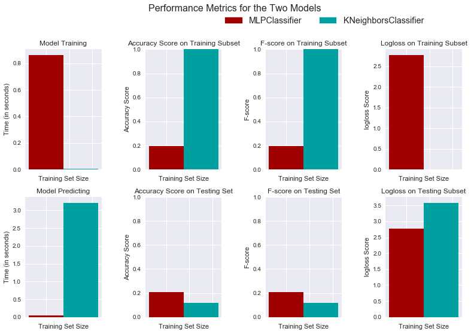

```
KNeighborsClassifier finish training
MLPClassifier finish training
model: MLPClassifier
train time:	1.0919640064239502
acc_train:	0.17292114399074227
f_train:	0.17292114399074224
logloss_train	2.7555165703534374
======================================================================================
pred time:	0.05552935600280762
acc_test:	0.15922619047619047
f_test:	0.15922619047619047
logloss_test	2.7820364170742766
======================================================================================
======================================================================================
model: KNeighborsClassifier
train time:	0.005220890045166016
acc_train:	0.9998346834187469
f_train:	0.9998346834187469
logloss_train	0.0002291774444296125
======================================================================================
pred time:	3.759580612182617
acc_test:	0.10962301587301587
f_test:	0.10962301587301587
logloss_test	3.571820959456243
======================================================================================
======================================================================================
```

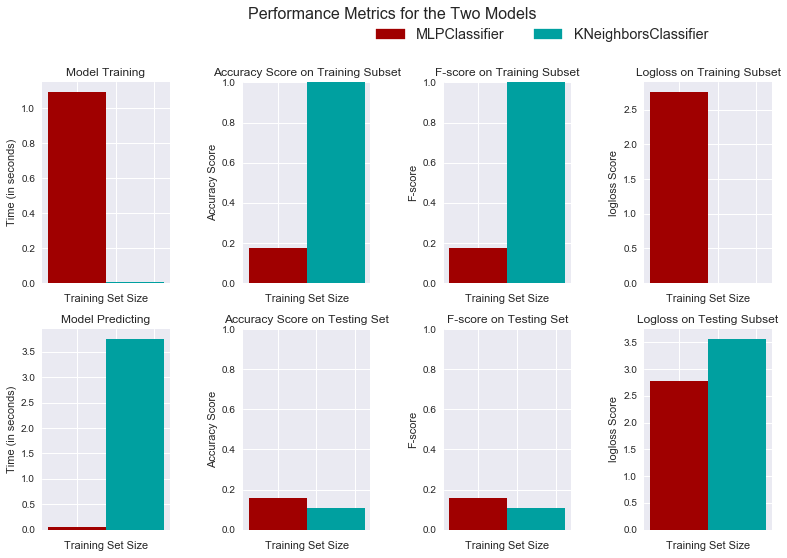

```
KNeighborsClassifier finish training
MLPClassifier finish training
model: MLPClassifier
train time:	1.540255069732666
acc_train:	0.19623078194742932
f_train:	0.19623078194742932
logloss_train	2.752781029342982
======================================================================================
pred time:	0.057460784912109375
acc_test:	0.19990079365079366
f_test:	0.19990079365079366
logloss_test	2.7726644213448988
======================================================================================
======================================================================================
model: KNeighborsClassifier
train time:	0.004677772521972656
acc_train:	0.9998346834187469
f_train:	0.9998346834187469
logloss_train	0.00022917744442960876
======================================================================================
pred time:	3.608919620513916
acc_test:	0.11408730158730158
f_test:	0.11408730158730158
logloss_test	3.4649905145901516
======================================================================================
======================================================================================
```

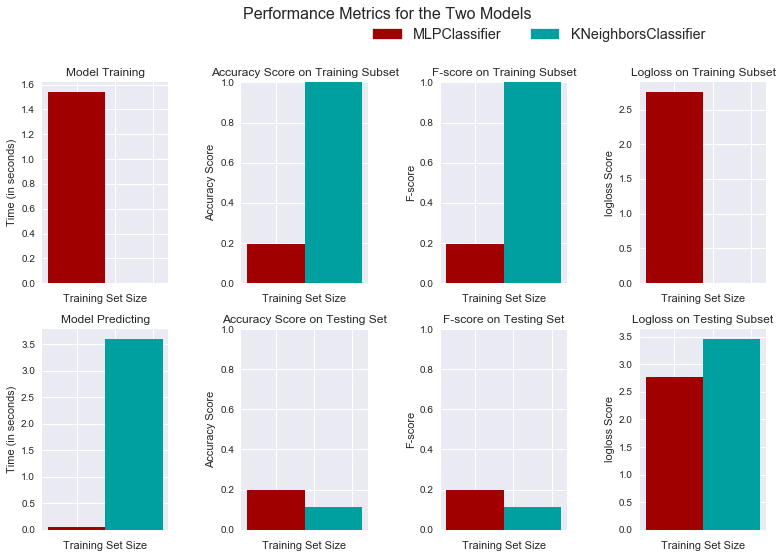

```
KNeighborsClassifier finish training
MLPClassifier finish training
model: MLPClassifier
train time:	1.0250906944274902
acc_train:	0.19507356587865762
f_train:	0.19507356587865762
logloss_train	2.7756484124768694
======================================================================================
pred time:	0.054483652114868164
acc_test:	0.20535714285714285
f_test:	0.20535714285714285
logloss_test	2.770360752662983
======================================================================================
======================================================================================
model: KNeighborsClassifier
train time:	0.003495454788208008
acc_train:	1.0
f_train:	1.0
logloss_train	3.88198317928128e-14
======================================================================================
pred time:	3.6659581661224365
acc_test:	0.11607142857142858
f_test:	0.11607142857142858
logloss_test	3.5913486688935694
======================================================================================
======================================================================================
```

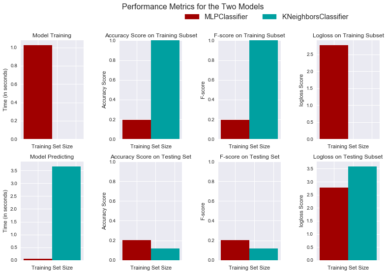

```python
from sklearn.model_selection import KFold
kf = KFold(n_splits=4, shuffle=True, random_state=85)
for train_index, test_index in kf.split(reduced_data):
    X_train, X_test = features.values[train_index], features.values[test_index]
    y_train, y_test = categories_number[train_index],categories_number[test_index]
    results = evaluate([learner_knn,learner_MLP],X_train, y_train ,X_test, y_test)
    vs_evaluate(results)
```

### Model Tuning

We will now tune MLPClassifier (neural net) parameter to get better results as the F-score and Accuracy score is better than KNN (k-nearest neighbors)

```python
from sklearn.model_selection import GridSearchCV
# parameters = {'solver': ['lbfgs','sgd','adam'],'learning_rate':['invscaling','adaptive'],'learning_rate_init':[0.001,0.0001] }
parameters = {'activation':['relu','logistic','tanh'], 'solver': ['sgd'], 'learning_rate':['adaptive'], 'alpha': 10.0 ** -np.arange(1,5), 'learning_rate_init':[0.001], 'max_iter':[1000,1100,1200]}
clf = GridSearchCV(MLPClassifier(shuffle=True), parameters, n_jobs=-1)
clf_fit = clf.fit(X_train, y_train)
# Get the estimator
best_clf = clf_fit.best_estimator_
```

### Applying the best model on the given test set

We will use the transformed data set for testing

```python
best_predictions = best_clf.predict_proba(transformed_test)
answer = pd.DataFrame(best_predictions ,columns=categories)
answer.to_csv('all/answer_best_MLP.csv', sep=',', index_label = 'Id')
```

After saving the output into csv file and submitting it to Kaggle competition, it gives a score = 2.68353